# GLMM evaluation

Hao Lu

June 15, 2019

## Set up environment

```r
library(readxl)
library(magrittr)
library(lme4)
library(car)
library(tidyverse)
library(lsmeans)
```

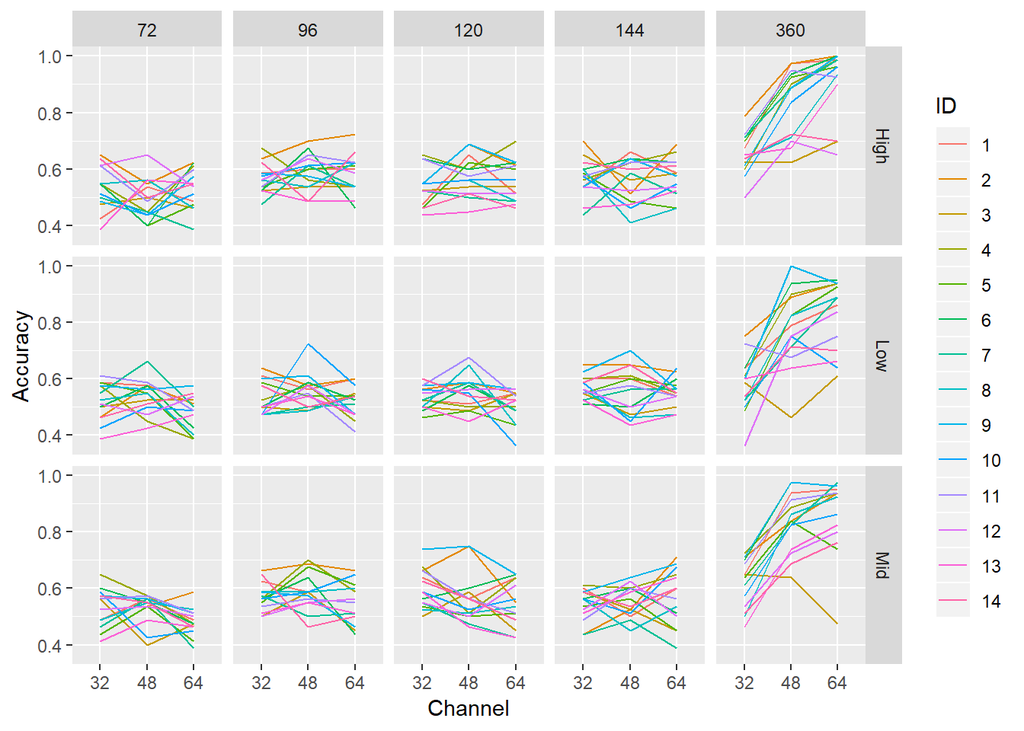

```r
CI_data <- read_excel("M:/Lab_Shared/HaoLu/GLMM_Anoo/GLMM_stats_dataset.xlsx")

# Set categorical data as factors:
CI_data$ID %<>% as.factor()
CI_data$Slope %<>% as.factor()
CI_data$Position %<>% as.factor()
CI_data$Channel %<>% as.factor()

# Convert accuracy to success and failure count
CI_data$Accuracy = CI_data$Accuracy/100
CI_data$Response = cbind(CI_data$Accuracy * 80,(1-CI_data$Accuracy)*80)

#default contrast setting does not satisfy type-III anova assumption
options(contrasts = c('contr.sum','contr.poly'))

# Plot data
ggplot(CI_data,aes(x=Channel,y=Accuracy,group=ID,color=ID))+geom_line()+facet_grid(Position~Slope)
```

Each row shows accuracy of a Condition and each column shows accuracy of a Slope.

According to the plot above and results of repeated measure ANOVA, dataset was split into two subsets before fitting model (Slope = 360 and other slope).

```r
# Split data into two groups
CI_data_exp1 = CI_data[CI_data$Slope==360,]
CI_data_exp2 = CI_data[CI_data$Slope!=360,]
```

## Fitting full models

The reviewer suggested to fit generalized linear mixed model (GLMM) using logit link function with lme4 R package.

Considering sample size and our general assumption, the best full model we can fit is the model with random intercept for each participant. Two GLMMs were fitted for experiment 1 and experiment 2.

```r
m.1.full = glmer(Response ~ Position*Channel+(1|ID), data=CI_data_exp1, family='binomial'('logit'))
m.2.full = glmer(Response ~ Slope*Position*Channel+(1|ID), data=CI_data_exp2, family='binomial'('logit'))
```

## Testing effect

Jaeger(2007) demonstrated example where fixed effect in GLMM were tested with Wald’s Z test. This test is used to test if one parameter in the model is zero. In our case, because there are factors with multiple levels, more than one parameter was used to model an effect. For example, levels of position was fitted with three parameters: low(intercept), mid-low, high-low. Therefore, we applied parametric bootstrapping method suggested by Ben Bolker (https://bbolker.github.io/mixedmodels-misc/glmmFAQ.html) and realized by Henrik Singmann (http://www2.uaem.mx/r-mirror/web/packages/afex/afex.pdf).

(The following results are output from Henrik Singmann’s afex::mix and it was copy and pasted because it usually take hours to run bootstrap simulation, 500 simulation was used here)

Experiment 1 model

Model: Response ~ Position * Channel + (1 | ID)

Data: CI_data_exp1

```
        Effect df     Chisq p.value
```

1 Position 2 63.49 ** .002

2 Channel 2 659.33 ** .004

3 Position:Channel 4 10.23 * .03

Experiment 2 model

Mixed Model Anova Table (Type 3 tests, PB-method)

Data: CI_data_exp2 Effect df Chisq p.value

1 Slope 3 60.29 ** .002

2 Position 2 15.00 ** .002

3 Channel 2 9.21 * .02

4 Slope:Position 6 12.44 + .05

5 Slope:Channel 6 9.91 + .09

6 Position:Channel 4 11.09 * .03

7 Slope:Position:Channel 12 16.88 .15

```r
m.2.alt = glmer(Response ~ Slope+Position+Channel++Slope:Channel +(1|ID), data=CI_data_exp2, family='binomial')
anova(m.2.full,m.2.alt)
```

```
## Data: CI_data_exp2
## Models:
## m.2.alt: Response ~ Slope + Position + Channel + +Slope:Channel + (1 |
## m.2.alt:     ID)
## m.2.full: Response ~ Slope * Position * Channel + (1 | ID)
##          Df    AIC    BIC  logLik deviance  Chisq Chi Df Pr(>Chisq)
## m.2.alt  15 3068.8 3132.1 -1519.4   3038.8
## m.2.full 37 3072.3 3228.5 -1499.2   2998.3 40.464     22   0.009538 **
## ---
## Signif. codes:  0 '***' 0.001 '**' 0.01 '*' 0.05 '.' 0.1 ' ' 1
```

The likelihood ratio test showed that the simpler model’s deviance was significantly larger than the full model, but by reducing parameters, we have both better AIC and BIC, so to avoid overfitting problem, the simpler model was used for further analysis.

## Comparison with chance level (50%)

```r
m.1.means = lsmeans(m.1.full,pairwise~Position:Channel)
summary(m.1.means,null=0,infer=c(TRUE,TRUE),adjust='bon')$lsmeans
```

```
##  Position Channel lsmean    SE  df asymp.LCL asymp.UCL z.ratio p.value
##  High     32       0.671 0.149 Inf    0.2574     1.085  4.497  0.0001
##  Low      32       0.330 0.148 Inf   -0.0808     0.742  2.228  0.2329
##  Mid      32       0.516 0.149 Inf    0.1034     0.928  3.468  0.0047
##  High     48       1.718 0.158 Inf    1.2799     2.156 10.879  <.0001
##  Low      48       1.310 0.153 Inf    0.8852     1.736  8.546  <.0001
##  Mid      48       1.691 0.158 Inf    1.2541     2.128 10.733  <.0001
##  High     64       2.383 0.170 Inf    1.9102     2.855 13.984  <.0001
##  Low      64       1.619 0.157 Inf    1.1850     2.054 10.339  <.0001
##  Mid      64       1.912 0.161 Inf    1.4663     2.358 11.892  <.0001
##
## Results are given on the logit (not the response) scale.
## Confidence level used: 0.95
## Conf-level adjustment: bonferroni method for 9 estimates
## P value adjustment: bonferroni method for 9 tests
```

The results above showed that except 32 channel and low position condition, all effects were significantly above chance level (p<0.005 after bonferroni correction)

```r
m.2.means = lsmeans(m.2.alt,pairwise~Position:Channel:Slope)
summary(m.2.means,null=0,infer=c(TRUE),adjust='bon')$lsmeans
```

```
##  Position Channel Slope   lsmean     SE  df asymp.LCL asymp.UCL z.ratio
##  High     32      72     0.14460 0.0490 Inf  -0.01219    0.3014  2.948
##  Low      32      72     0.05407 0.0490 Inf  -0.10266    0.2108  1.103
##  Mid      32      72     0.12432 0.0490 Inf  -0.03246    0.2811  2.535
##  High     48      72     0.11945 0.0490 Inf  -0.03729    0.2762  2.436
##  Low      48      72     0.02892 0.0490 Inf  -0.12777    0.1856  0.590
##  Mid      48      72     0.09917 0.0490 Inf  -0.05756    0.2559  2.023
##  High     64      72     0.02379 0.0490 Inf  -0.13287    0.1805  0.486
##  Low      64      72    -0.06673 0.0490 Inf  -0.22338    0.0899 -1.362
##  Mid      64      72     0.00351 0.0490 Inf  -0.15315    0.1602  0.072
##  High     32      96     0.26256 0.0492 Inf   0.10537    0.4197  5.340
##  Low      32      96     0.17203 0.0491 Inf   0.01494    0.3291  3.501
##  Mid      32      96     0.24228 0.0492 Inf   0.08512    0.3994  4.928
##  High     48      96     0.35875 0.0493 Inf   0.20104    0.5165  7.272
##  Low      48      96     0.26822 0.0493 Inf   0.11063    0.4258  5.441
##  Mid      48      96     0.33847 0.0493 Inf   0.18079    0.4961  6.863
##  High     64      96     0.24080 0.0491 Inf   0.08371    0.3979  4.901
##  Low      64      96     0.15028 0.0491 Inf  -0.00673    0.3073  3.060
##  Mid      64      96     0.22052 0.0491 Inf   0.06345    0.3776  4.488
##  High     32      120    0.26619 0.0492 Inf   0.10898    0.4234  5.413
##  Low      32      120    0.17566 0.0491 Inf   0.01855    0.3328  3.574
##  Mid      32      120    0.24590 0.0492 Inf   0.08873    0.4031  5.002
##  High     48      120    0.29408 0.0492 Inf   0.13674    0.4514  5.975
##  Low      48      120    0.20355 0.0492 Inf   0.04631    0.3608  4.139
##  Mid      48      120    0.27380 0.0492 Inf   0.11649    0.4311  5.564
##  High     64      120    0.18420 0.0491 Inf   0.02731    0.3411  3.753
##  Low      64      120    0.09368 0.0491 Inf  -0.06315    0.2505  1.910
##  Mid      64      120    0.16392 0.0491 Inf   0.00705    0.3208  3.341
##  High     32      144    0.28437 0.0492 Inf   0.12708    0.4417  5.780
##  Low      32      144    0.19384 0.0492 Inf   0.03665    0.3510  3.942
##  Mid      32      144    0.26408 0.0492 Inf   0.10682    0.4213  5.368
##  High     48      144    0.26135 0.0492 Inf   0.10417    0.4185  5.316
##  Low      48      144    0.17082 0.0491 Inf   0.01373    0.3279  3.476
##  Mid      48      144    0.24107 0.0492 Inf   0.08391    0.3982  4.904
##  High     64      144    0.29651 0.0492 Inf   0.13916    0.4539  6.024
##  Low      64      144    0.20599 0.0492 Inf   0.04874    0.3632  4.188
##  Mid      64      144    0.27623 0.0492 Inf   0.11891    0.4336  5.613
##  p.value
##  0.1150
##  1.0000
```

[output cut: 24 more lines]

```
##  0.0301
##  <.0001
##  0.0029
##  <.0001
##  <.0001
##  0.0183
##  <.0001
##  <.0001
##  0.0010
##  <.0001
##
## Results are given on the logit (not the response) scale.
## Confidence level used: 0.95
## Conf-level adjustment: bonferroni method for 36 estimates
## P value adjustment: bonferroni method for 36 tests
```